# Commission Analysis

Jonas Gehrlein @ Web3 Foundation

25/01/2022

```r
# Specify if code should be shown in export
show_code = FALSE
# Specify which network you would like to analyze. Must be "polkadot" or "kusama".
chain = "kusama"
# Specify which session you would like to analyze. Must be >= 419 for Polkadot and >= 5994 for KSM.
session = 18929
```

# Descriptive metrics

The following data only includes active validators of session 18929.

|  | kusama |
| --- | --- |
| Average commission: | **52.81%** |
| Number of validators with 100% commission: | **498** |
| Number of validators with <100% commission | **502** |
| Average commission for validators with <100% commission: | **6%** |

Further on, I only include validators that have <50% commission.

# Distribution of Validator Identity

The following table groups validators into operators by comparing the first few strings of their identity. This is not a perfect measure, but good enough. We also have a large group of validators that did not register an identity (pseudo-a group).

|  | short_identity | number_nodes | self_stake_mean | commission_percent_mean | fraction |
| --- | --- | --- | --- | --- | --- |
| 174 | Zug | 67 | 10000000000000 | 2.5000000 | 0.136 |
| 123 | P2P. | 64 | 4716482183576 | 2.0000000 | 0.130 |
| 132 | pseudo-a. | 46 | 115302691560522 | 7.1304348 | 0.093 |
| 84 | Jaco | 30 | 1000002222262 | 2.0000000 | 0.061 |
| 11 | 🐠 st | 20 | 100000000000 | 4.0000000 | 0.041 |
| 138 | RYAB | 12 | 4305271124047 | 3.0000000 | 0.024 |
| 43 | bloc | 10 | 1381269729440 | 4.7000000 | 0.020 |
| 148 | Stak | 10 | 65137356315726 | 5.2000000 | 0.020 |
| 149 | STAK | 9 | 84461109977369 | 1.3333333 | 0.018 |
| 124 | Para | 5 | 18000044468961 | 2.0000000 | 0.010 |
| 173 | ZKVa | 5 | 10000000000 | 10.0000000 | 0.010 |
| 57 | Dion | 4 | 52426570890444 | 5.0000000 | 0.008 |
| 76 | Gold | 4 | 29550006032126 | 12.5000000 | 0.008 |
| 137 | Rock | 4 | 6346958341395 | 10.0000000 | 0.008 |
| 26 | ALLN | 3 | 46676988444355 | 5.0000000 | 0.006 |
| 75 | Gene | 3 | 83557894715777 | 3.3333333 | 0.006 |
| 87 | Keep | 3 | 17333333333333 | 2.0000000 | 0.006 |
| 129 | POLK | 3 | 5222904437492 | 0.6666667 | 0.006 |
| 133 | Pure | 3 | 183309613738533 | 6.6666667 | 0.006 |
| 135 | redp | 3 | 18029531214082 | 20.0000000 | 0.006 |
| 1 | **** | 2 | 59672199527623 | 10.0000000 | 0.004 |
| 2 | ☀️Sh | 2 | 9501271659154 | 0.0000000 | 0.004 |
| 5 | ✨Ziz | 2 | 31290478792576 | 10.0000000 | 0.004 |
| 13 | 🔒sta | 2 | 50301804868323 | 10.0000000 | 0.004 |
| 14 | 🗻Bas | 2 | 35666608454767 | 10.0000000 | 0.004 |
| 15 | 🤖 Po | 2 | 332874633345412 | 6.5000000 | 0.004 |
| 28 | Amfo | 2 | 50000000000000 | 5.0000000 | 0.004 |
| 29 | Amig | 2 | 97487203315296 | 10.0000000 | 0.004 |
| 41 | Biso | 2 | 84817183057756 | 10.0000000 | 0.004 |
| 44 | BRAV | 2 | 96255209679544 | 10.0000000 | 0.004 |

[output cut: 145 more lines]

# Commission of smaller node operators

Let’s break down the above data for smaller operators that have 6 or less nodes (and can be identified). The full list of operators can be found in Appendix A1. The histogram shows the distribution of average commission per operator.

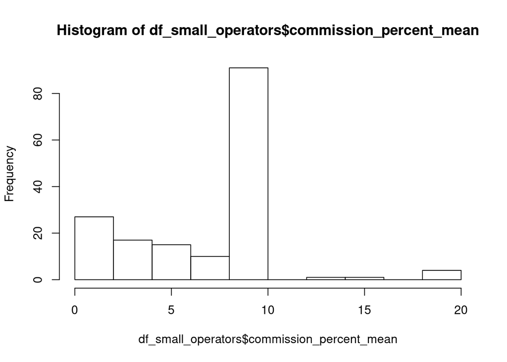

```r
df_small_operators <- subset(df_table, number_nodes <= cutoff)
df_big_operators <- subset(df_table, number_nodes > cutoff)
hist(df_small_operators$commission_percent_mean)
```

The mean of the average commission of small node operators is 7.4558233% vs. larger node operators with 3.5404187%. A minimum commission of 3% would affect 27 (16.2650602%) small node operators and 4 (44.4444444%) big operators. However, in total, this change would affect 42 nodes of small operators and 170 of big operators.

# Determinants of votes

The following analysis is a simple linear regression that predicts the number of votes per validator (pre-phragmen) by their commission, identity and self-stake.

```r
validators_use$identity = ifelse(validators_use$name == "",0,1)
validators_regression = subset(validators_use, commission_percent<50,
select=c(identity,self_stake,commission_percent,num_voters))
linearModel = glm(num_voters ~ commission_percent + identity + self_stake, family=gaussian(link="identity"), data=validators_regression )
summary(linearModel)
```

```
##
## Call:
## glm(formula = num_voters ~ commission_percent + identity + self_stake,
##     family = gaussian(link = "identity"), data = validators_regression)
##
## Deviance Residuals:
##     Min       1Q   Median       3Q      Max
## -166.11  -105.36   -63.58     1.38  1223.37
##
## Coefficients:
##                      Estimate Std. Error t value Pr(>|t|)
## (Intercept)         1.047e+02  3.747e+01   2.795   0.0054 **
## commission_percent -1.095e+01  2.384e+00  -4.594 5.53e-06 ***
## identity            6.939e+01  3.541e+01   1.960   0.0506 .
## self_stake          8.920e-16  1.106e-14   0.081   0.9357
## ---
## Signif. codes:  0 '***' 0.001 '**' 0.01 '*' 0.05 '.' 0.1 ' ' 1
##
## (Dispersion parameter for gaussian family taken to be 51202.33)
##
##     Null deviance: 26477659  on 492  degrees of freedom
## Residual deviance: 25037938  on 489  degrees of freedom
## AIC: 6750.9
##
## Number of Fisher Scoring iterations: 2
```

The above data shows that, of the independent variables included, the commission is the main driver in deciding for a nominator to nominate a validator. Particularly it means that a 1% increase in commission leads to a loss of 10 voters.

# A1: Full list of smaller node operators

```r
knitr::kable(df_small_operators, format="simple", format.args = list(scientific = FALSE))
```

|  | short_identity | number_nodes | self_stake_mean | commission_percent_mean | fraction |
| --- | --- | --- | --- | --- | --- |
| 124 | Para | 5 | 18000044468961 | 2.0000000 | 0.010 |
| 173 | ZKVa | 5 | 10000000000 | 10.0000000 | 0.010 |
| 57 | Dion | 4 | 52426570890444 | 5.0000000 | 0.008 |
| 76 | Gold | 4 | 29550006032126 | 12.5000000 | 0.008 |
| 137 | Rock | 4 | 6346958341395 | 10.0000000 | 0.008 |
| 26 | ALLN | 3 | 46676988444355 | 5.0000000 | 0.006 |
| 75 | Gene | 3 | 83557894715777 | 3.3333333 | 0.006 |
| 87 | Keep | 3 | 17333333333333 | 2.0000000 | 0.006 |
| 129 | POLK | 3 | 5222904437492 | 0.6666667 | 0.006 |
| 133 | Pure | 3 | 183309613738533 | 6.6666667 | 0.006 |
| 135 | redp | 3 | 18029531214082 | 20.0000000 | 0.006 |
| 1 | **** | 2 | 59672199527623 | 10.0000000 | 0.004 |
| 2 | ☀️Sh | 2 | 9501271659154 | 0.0000000 | 0.004 |
| 5 | ✨Ziz | 2 | 31290478792576 | 10.0000000 | 0.004 |
| 13 | 🔒sta | 2 | 50301804868323 | 10.0000000 | 0.004 |
| 14 | 🗻Bas | 2 | 35666608454767 | 10.0000000 | 0.004 |
| 15 | 🤖 Po | 2 | 332874633345412 | 6.5000000 | 0.004 |
| 28 | Amfo | 2 | 50000000000000 | 5.0000000 | 0.004 |
| 29 | Amig | 2 | 97487203315296 | 10.0000000 | 0.004 |
| 41 | Biso | 2 | 84817183057756 | 10.0000000 | 0.004 |
| 44 | BRAV | 2 | 96255209679544 | 10.0000000 | 0.004 |
| 47 | CAPI | 2 | 1691195412083 | 0.0000000 | 0.004 |
| 49 | Chor | 2 | 100000000000 | 8.0000000 | 0.004 |
| 50 | Comp | 2 | 53914142181182 | 10.0000000 | 0.004 |
| 61 | EARN | 2 | 6873607106946 | 0.0000000 | 0.004 |
| 62 | Eat | 2 | 12344372147309 | 10.0000000 | 0.004 |
| 65 | Eric | 2 | 200092604384986 | 3.0000000 | 0.004 |
| 81 | ilgi | 2 | 69371755087240 | 10.0000000 | 0.004 |
| 97 | luck | 2 | 62200872065740 | 15.0000000 | 0.004 |
| 98 | Luck | 2 | 108460989071892 | 6.5000000 | 0.004 |

[output cut: 136 more lines]